# Семинар 2. Таблицы сопряжённости, корреляции и манипуляции с данными

May 28, 2018

# 1 Гремучая смесь R и маркдаун

В нашем документе смешан код R внутри сереньких блоков и текст с разметкой маркдаун. Эту смесь можно превратить в готовый документ, нажав на клубок ниток со словом `Knit` прямо над документом.

Попробуйте кликнуть `Knit`:)

Будьте осторожны при редактировании R-маркдаун! Например, если Вовочка удалит один закрывающий разделитель, то компьютер будет воспринимать человеческий текст как команды R и выдаст ошибку.

Основные опции блоков кода: - message=TRUE/FALSE - выводить ли в отчёт *сообщения* - warning=TRUE/FALSE - выводить ли в отчёт *предупреждения* - echo=TRUE/FALSE - копировать ли в отчёт сами команды R - eval=TRUE/FALSE - выполнять ли команды внутри блока кода - “Самый важный шмат кода” - название блока кода :)

Подробнее про фантастические возможности R+маркдаун: `Help` - `Cheatsheets` - `R markdown`.

Сделайте свой Rstudio уютненьким: `Tools` - `Global Options` - `Appearance` :)

# 2 Работа с очень качественными переменными.

В R есть много типов переменных, например: - количественные (double, dbl) - целочисленные (integer, int) - дата и время (datetime, dttm) - логические (logical, lgl) - качественные/категориальные/факторные (factor, fctr) - текстовые (character, chr)

Существенной разницы между текстовыми и качественными нет. Отличия качественных от текстовых: - ограничено количество значений, скажем только “зима”, “весна”, “лето”, “осень” - можно задать порядок “магистр” > “бакалавр” > “школьник” - занимают меньше места в памяти

Подключаем нужные пакеты и вперёд!

```r
library(tidyverse) # обработка данных, графики...
library(vcd) # мозаичные графики для качественных переменных
```

```r
library(skimr) # описательные статистики
library(rio) # импорт фантастического количества форматов данных
library(ggalluvial) # потоковые ???? графики для качественных переменных
library(nycflights13) # набор данных о вылетах из Нью-Йорка
library(corrplot) # визуализация корреляций
library(reshape2) # длинные и широкие таблицы
```

Узнаём частотность каждой категории переменной `color`:

```r
table(diamonds$color)
```

```
##
##     D     E     F     G     H     I     J
##  6775  9797  9542 11292  8304  5422  2808
```

Или получаем список категорий без количеств:

```r
levels(diamonds$color)
```

```
## [1] "D" "E" "F" "G" "H" "I" "J"
```

Попробуем объединить три категории в одну: “D”, “E”, “F” в “United”:

```r
diamonds2 <- mutate(diamonds, color = fct_collapse(color, United = c('D', 'E', 'F')))
table(diamonds2$color)
```

```
##
## United      G      H      I      J
##  26114  11292   8304   5422   2808
```

- Упражнение 1.

Объедините категории “Premium” и “Ideal” огранки `cut` в категорию ‘Best’. Обратите внимание на то, какие названия пишутся в кавычках.

```r
# diamonds3 <- mutate(diamonds, cut = fct_collapse(___, ___))
# table(diamonds3$cut)
```

# 3 Таблицы сопряжённости

Рассмотрим данные по зарплатам со страницы [UCI](http://archive.ics.uci.edu/ml/machine-learning-databases/adult/). Загружаем и смотрим на них:

```r
adult <- import('adult.rds') # загружаем данные
glimpse(adult)
```

```
## Observations: 32,561
## Variables: 15
## $ V1  <int> 39, 50, 38, 53, 28, 37, 49, 52, 31, 42, 37, 30, 23, 32, 40...
## $ V2  <fct> State-gov, Self-emp-not-inc, Private, Private, Private, Pr...
## $ V3  <int> 77516, 83311, 215646, 234721, 338409, 284582, 160187, 2096...
## $ V4  <fct> Bachelors, Bachelors, HS-grad, 11th, Bachelors, Masters, 9...
## $ V5  <int> 13, 13, 9, 7, 13, 14, 5, 9, 14, 13, 10, 13, 13, 12, 11, 4,...
## $ V6  <fct> Never-married, Married-civ-spouse, Divorced, Married-civ-s...
## $ V7  <fct> Adm-clerical, Exec-managerial, Handlers-cleaners, Handlers...
## $ V8  <fct> Not-in-family, Husband, Not-in-family, Husband, Wife, Wife...
## $ V9  <fct> White, White, White, Black, Black, White, Black, White, Wh...
## $ V10 <fct> Male, Male, Male, Male, Female, Female, Female, Male, Fema...
## $ V11 <int> 2174, 0, 0, 0, 0, 0, 0, 0, 14084, 5178, 0, 0, 0, 0, 0, 0, ...
## $ V12 <int> 0, 0, 0, 0, 0, 0, 0, 0, 0, 0, 0, 0, 0, 0, 0, 0, 0, 0, 0, 0...
## $ V13 <int> 40, 13, 40, 40, 40, 40, 16, 45, 50, 40, 80, 40, 30, 50, 40...
## $ V14 <fct> United-States, United-States, United-States, United-States...
## $ V15 <fct> <=50K, <=50K, <=50K, <=50K, <=50K, <=50K, <=50K, >50K, >50...
```

Переменные в файле были без названий и потому R их сиротливо назвал `V1`, `V2` :) Полное [описание переменных UCI](http://archive.ics.uci.edu/ml/machine-learning-databases/adult/adult.names).

```r
adult2 <- select(adult, sector = V2, race = V10, wage = V15)
glimpse(adult2)
```

```
## Observations: 32,561
## Variables: 3
## $ sector <fct> State-gov, Self-emp-not-inc, Private, Private, Private,...
## $ race   <fct> Male, Male, Male, Male, Female, Female, Female, Male, F...
## $ wage   <fct> <=50K, <=50K, <=50K, <=50K, <=50K, <=50K, <=50K, >50K, ...
```

```r
skim(adult2)
```

```
## Skim summary statistics
##  n obs: 32561
##  n variables: 3
##
## ── Variable type:factor ───────────────────────────────────────────────────
##  variable missing complete     n n_unique
##      race       0    32561 32561        2
##    sector       0    32561 32561        9
##      wage       0    32561 32561        2
##                                 top_counts ordered
##              Mal: 21790, Fem: 10771, NA: 0   FALSE
##  Pri: 22696, Sel: 2541, Loc: 2093, ?: 1836   FALSE
##               <=5: 24720, >50: 7841, NA: 0   FALSE
```

- Упражнение 2:
- Сколько уникальных значений у переменных `wage` и `sector`?

Для качественных переменных можно создавать таблицы сопряжённости. По строкам указываются значения одной переменной, по столбцам — другой, а на пересечении стоит количество наблюдений.

Таблицу сопряжённости можно создать командой `table()`:

```r
table(adult2$sector, adult2$wage)
```

```
##
##                    <=50K  >50K
##   ?                 1645   191
##   Federal-gov        589   371
##   Local-gov         1476   617
##   Never-worked         7     0
##   Private          17733  4963
##   Self-emp-inc       494   622
##   Self-emp-not-inc  1817   724
##   State-gov          945   353
##   Without-pay         14     0
```

Девять значений переменной `sector`- довольно много для ясной визуализации!

Но мы уже знаем, как объединять переменные, поэтому всех трудящихся на государство различать не будем. Также объединим в одну категорию предпринимателей, значения `Self-emp-not-inc`, `Self-emp-inc`.

```r
adult3 <- mutate(adult2, sector = fct_collapse(sector, Gov = c('State-gov', 'Federal-gov', 'Local-gov')))
adult4 <- mutate(adult3, sector = fct_collapse(sector, Self_emp = c('Self-emp-not-inc', 'Self-emp-inc')))
skim(adult4)
```

```
## Skim summary statistics
##  n obs: 32561
##  n variables: 3
##
## ── Variable type:factor ───────────────────────────────────────────────────
##  variable missing complete     n n_unique
##      race       0    32561 32561        2
##    sector       0    32561 32561        6
##      wage       0    32561 32561        2
##                                 top_counts ordered
##              Mal: 21790, Fem: 10771, NA: 0   FALSE
##  Pri: 22696, Gov: 4351, Sel: 3657, ?: 1836   FALSE
##               <=5: 24720, >50: 7841, NA: 0   FALSE
```

Строим более компактную таблицу сопряжённости:

```r
ctable <- table(adult4$sector, adult4$wage, dnn = c('Сектор', 'Зарплата'))
ctable
```

```
##               Зарплата
## Сектор   <=50K  >50K
##   ?             1645   191
##   Gov           3010  1341
##   Never-worked     7     0
##   Private      17733  4963
##   Self_emp      2311  1346
##   Without-pay     14     0
```

Визуализировать таблицу сопряжённости можно командой `mosaic()` из пакета `vcd`.

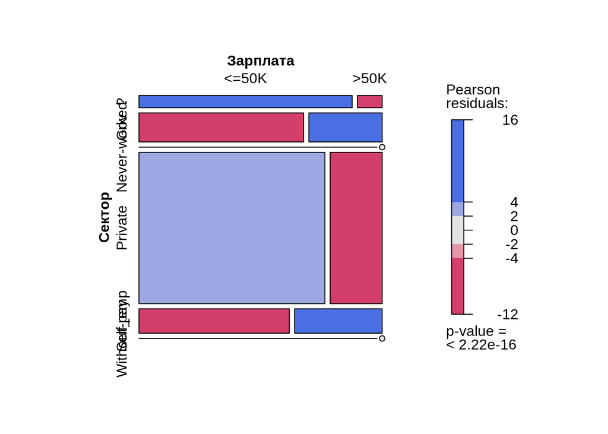

```r
mosaic(ctable, shade = TRUE, legend = TRUE)
```

Внутри функции сидит сама таблицу сопряжённости и опции: - `shade = TRUE`, чтобы график был цветным; - `legend = TRUE`, чтобы появилась легенда.

Можно ли считать зарплату и сектор независимыми признаками? Ответ даёт хи-квадрат тест Пирсона на независимость, `chisq.test()`.

```r
chisq.test(ctable)
```

```
##
##  Pearson's Chi-squared test
##
## data:  ctable
## X-squared = 687.39, df = 5, p-value < 2.2e-16
```

- Какой вывод можно сделать? Зависимы ли признаки?
- Упражнение 3.

Возьмём встроенный набор данных `Arthritis` о лечения артрита. - Посмотрите на описательные статистики. Сколько наблюдений в данных? - Сколько уникальных значений принимают факторные переменные? - Составьте таблицу сопряжённости для переменных `Treatment` и `Improved`. Укажите названия переменных. - Постройте мозаичный график `mosaic()` для таблицы сопряжённости. - Протестируйте независимость признаков `Treatment` и `Improved` используя оператор “затем”

```r
dta <- Arthritis
# ___
# new_ctable <- table(___, ___, dnn = c('___', '___'))
# new_ctable
# mosaic(___, shade = ___, ___ = ___)

# new_ctable %>% ___() # применяем к таблице тест на независимость
```

## 3.1 Очень много качественных переменных

Если качественных переменных больше двух, то разумнее посчитать таблицу частот. Мы группируем наблюдения по трём переменным и для каждой группы считаем количество наблюдений `n()`.

```r
freq_table <- group_by(adult4, wage, race, sector) %>% summarise(freq = n())
freq_table
```

```
## # A tibble: 20 x 4
## # Groups:   wage, race [?]
##    wage  race   sector        freq
##    <fct> <fct>  <fct>        <int>
##  1 <=50K Female ?              787
##  2 <=50K Female Gov           1361
##  3 <=50K Female Never-worked     2
##  4 <=50K Female Private       7026
##  5 <=50K Female Self_emp       411
##  6 <=50K Female Without-pay      5
##  7 <=50K Male   ?              858
##  8 <=50K Male   Gov           1649
##  9 <=50K Male   Never-worked     5
## 10 <=50K Male   Private      10707
## 11 <=50K Male   Self_emp      1900
## 12 <=50K Male   Without-pay      9
## 13 >50K  Female ?               52
## 14 >50K  Female Gov            278
## 15 >50K  Female Private        726
## 16 >50K  Female Self_emp       123
## 17 >50K  Male   ?              139
## 18 >50K  Male   Gov           1063
## 19 >50K  Male   Private       4237
## 20 >50K  Male   Self_emp      1223
```

- Упражнение 4.

Опишите словами, что изображено на графике:

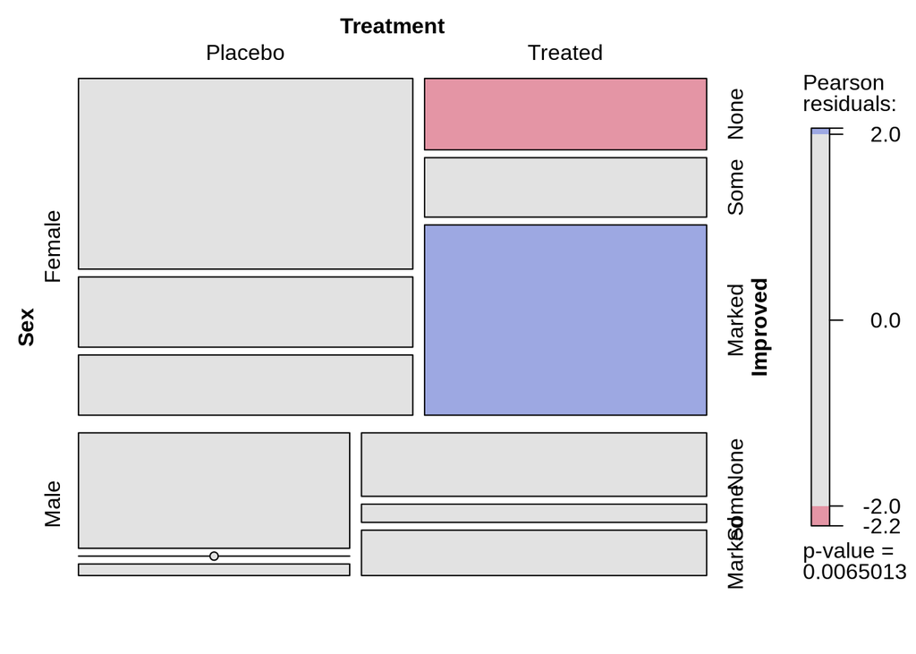

```r
mosaic(data = Arthritis, ~ Sex + Treatment + Improved, shade = TRUE, legend = TRUE)
```

# 4 Корреляционная матрица

Возьмём встроенный набор данных про автомобили `mtcars`. Напоминалка: посмотреть описание данных можно, набрав в консоли `?mtcars`.

- Упражнение 5.
- С помощью консоли вызовите справку и прочтите смысл переменных `cyl`, `mpg` и `am`.

Команда `cor()` поможет нам легко посчитать корреляции!

```r
glimpse(mtcars)
```

```
## Observations: 32
## Variables: 11
## $ mpg  <dbl> 21.0, 21.0, 22.8, 21.4, 18.7, 18.1, 14.3, 24.4, 22.8, 19....
## $ cyl  <dbl> 6, 6, 4, 6, 8, 6, 8, 4, 4, 6, 6, 8, 8, 8, 8, 8, 8, 4, 4, ...
## $ disp <dbl> 160.0, 160.0, 108.0, 258.0, 360.0, 225.0, 360.0, 146.7, 1...
## $ hp   <dbl> 110, 110, 93, 110, 175, 105, 245, 62, 95, 123, 123, 180, ...
## $ drat <dbl> 3.90, 3.90, 3.85, 3.08, 3.15, 2.76, 3.21, 3.69, 3.92, 3.9...
## $ wt   <dbl> 2.620, 2.875, 2.320, 3.215, 3.440, 3.460, 3.570, 3.190, 3...
## $ qsec <dbl> 16.46, 17.02, 18.61, 19.44, 17.02, 20.22, 15.84, 20.00, 2...
## $ vs   <dbl> 0, 0, 1, 1, 0, 1, 0, 1, 1, 1, 1, 0, 0, 0, 0, 0, 0, 1, 1, ...
## $ am   <dbl> 1, 1, 1, 0, 0, 0, 0, 0, 0, 0, 0, 0, 0, 0, 0, 0, 0, 1, 1, ...
## $ gear <dbl> 4, 4, 4, 3, 3, 3, 3, 4, 4, 4, 4, 3, 3, 3, 3, 3, 3, 4, 4, ...
## $ carb <dbl> 4, 4, 1, 1, 2, 1, 4, 2, 2, 4, 4, 3, 3, 3, 4, 4, 4, 1, 2, ...
```

```r
cars_cor <- cor(mtcars)
cars_cor
```

```
##             mpg        cyl       disp         hp        drat         wt
## mpg   1.0000000 -0.8521620 -0.8475514 -0.7761684  0.68117191 -0.8676594
## cyl  -0.8521620  1.0000000  0.9020329  0.8324475 -0.69993811  0.7824958
## disp -0.8475514  0.9020329  1.0000000  0.7909486 -0.71021393  0.8879799
## hp   -0.7761684  0.8324475  0.7909486  1.0000000 -0.44875912  0.6587479
## drat  0.6811719 -0.6999381 -0.7102139 -0.4487591  1.00000000 -0.7124406
## wt   -0.8676594  0.7824958  0.8879799  0.6587479 -0.71244065  1.0000000
## qsec  0.4186840 -0.5912421 -0.4336979 -0.7082234  0.09120476 -0.1747159
## vs    0.6640389 -0.8108118 -0.7104159 -0.7230967  0.44027846 -0.5549157
## am    0.5998324 -0.5226070 -0.5912270 -0.2432043  0.71271113 -0.6924953
## gear  0.4802848 -0.4926866 -0.5555692 -0.1257043  0.69961013 -0.5832870
## carb -0.5509251  0.5269883  0.3949769  0.7498125 -0.09078980  0.4276059
##             qsec         vs          am       gear        carb
## mpg   0.41868403  0.6640389  0.59983243  0.4802848 -0.55092507
## cyl  -0.59124207 -0.8108118 -0.52260705 -0.4926866  0.52698829
## disp -0.43369788 -0.7104159 -0.59122704 -0.5555692  0.39497686
## hp   -0.70822339 -0.7230967 -0.24320426 -0.1257043  0.74981247
## drat  0.09120476  0.4402785  0.71271113  0.6996101 -0.09078980
## wt   -0.17471588 -0.5549157 -0.69249526 -0.5832870  0.42760594
## qsec  1.00000000  0.7445354 -0.22986086 -0.2126822 -0.65624923
## vs    0.74453544  1.0000000  0.16834512  0.2060233 -0.56960714
## am   -0.22986086  0.1683451  1.00000000  0.7940588  0.05753435
## gear -0.21268223  0.2060233  0.79405876  1.0000000  0.27407284
## carb -0.65624923 -0.5696071  0.05753435  0.2740728  1.00000000
```

Если вдруг нужна корреляция не Пирсона, а Кендалла или Спирмена, добавьте аргумент `method = 'kendall'` или `method = 'spearman'`.

Для визуализации корреляционной матрицы попробуем команду `corrplot()` из одноимённого пакета. Настраивать можно всё, что угодно, от формы кружочков до количества знаков после запятой.

Всего лишь несколько вариантов:

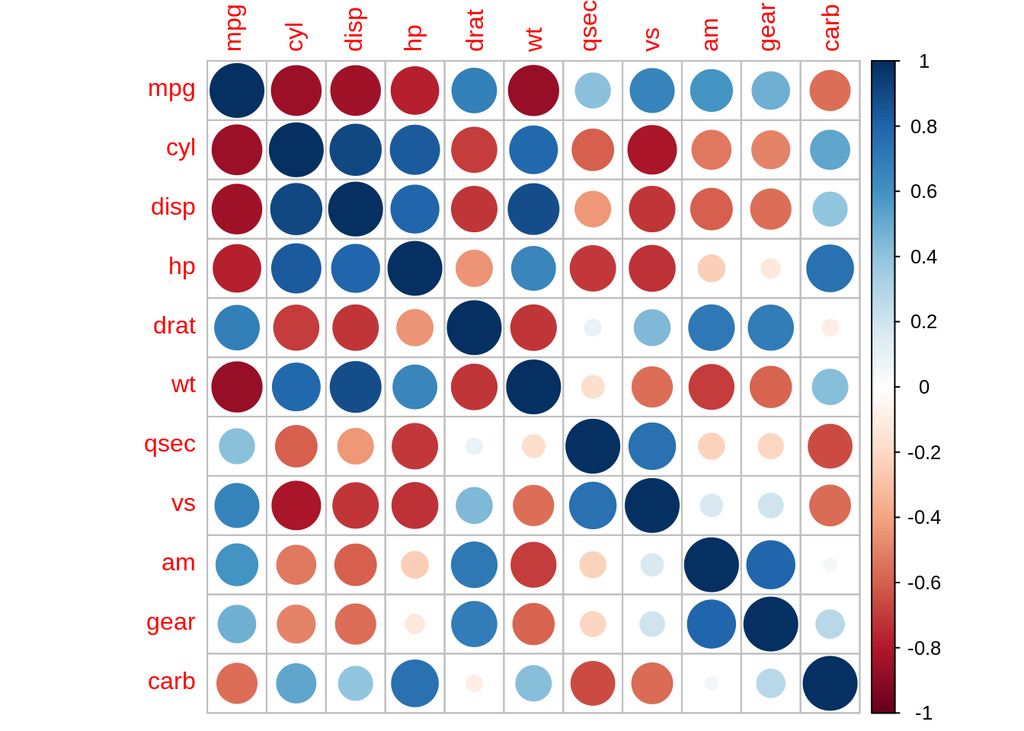

```r
corrplot(cars_cor) # график с аргументами по умолчанию
```

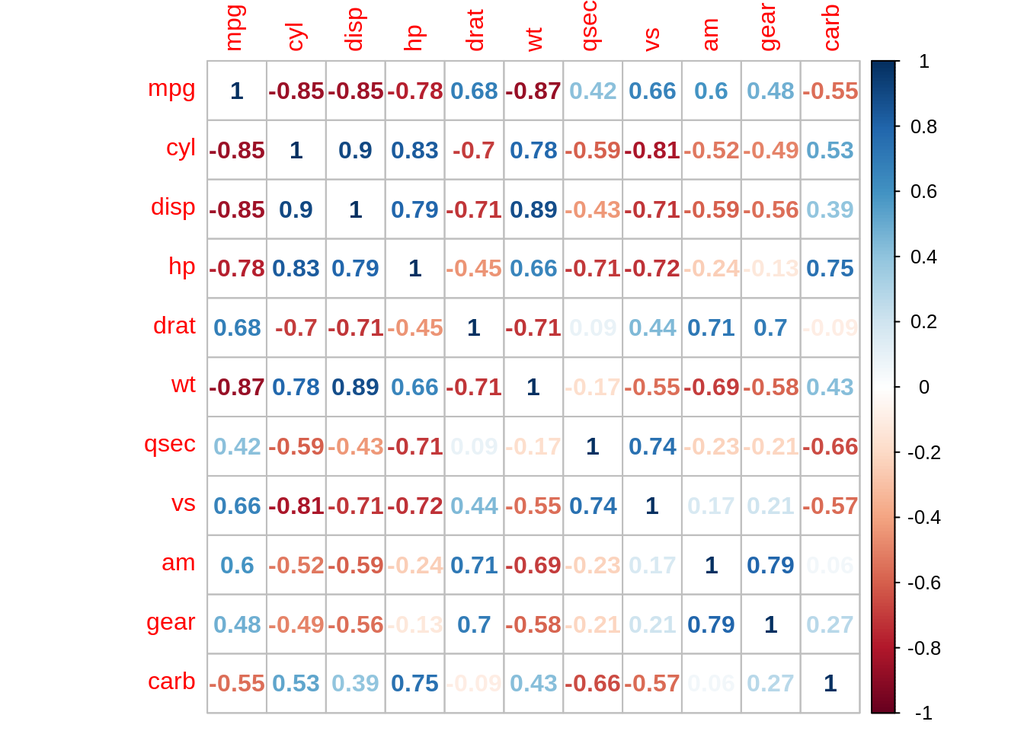

```r
corrplot(cars_cor, method = 'number') # график со значениями корреляции
```

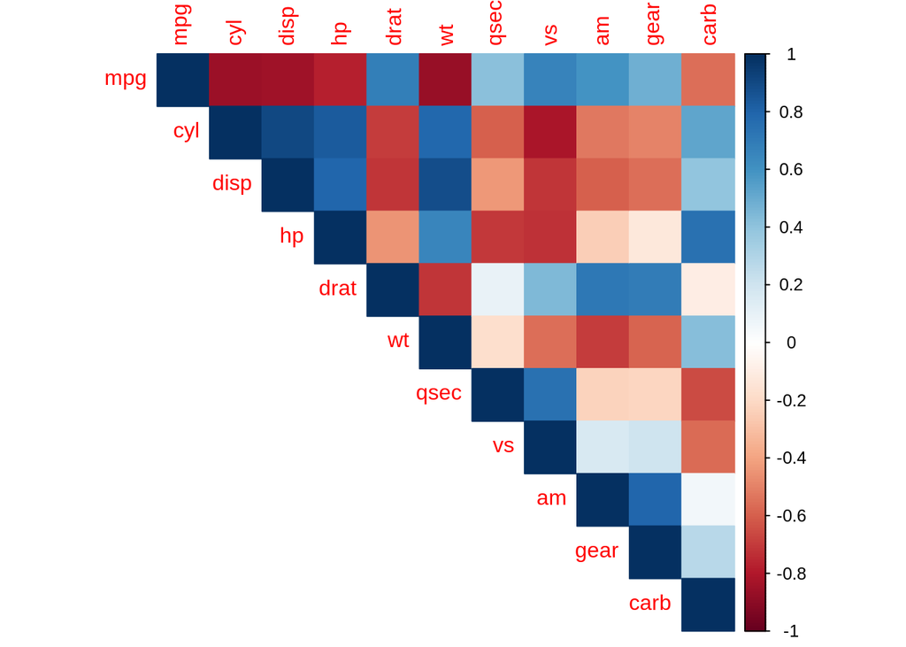

```r
corrplot(cars_cor, method = 'color', type = 'upper') # только правая верхняя часть
```

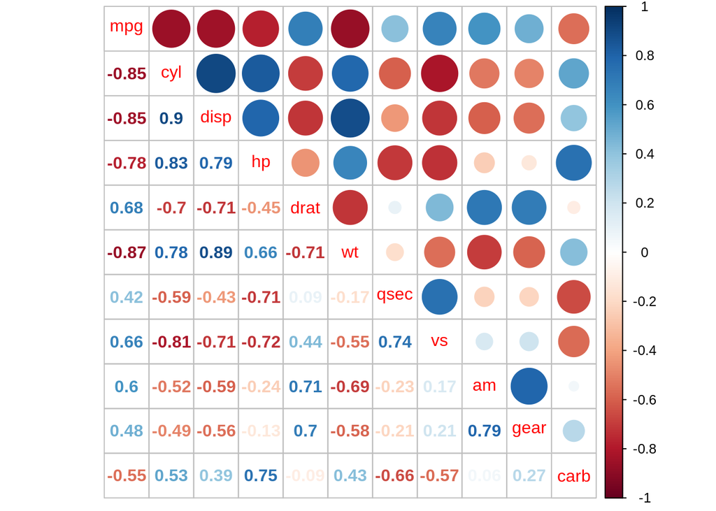

```r
corrplot.mixed(cars_cor) # можно миксовать!
```

Красивые примеры из [виньетки пакета](https://cran.r-project.org/web/packages/corrplot/vignettes/corrplot-intro.html). И менее красочная, но подробнейшая справка - `?corrplot`.

- Упражнение 6.

Возьмём таблицу `airquality`, ежедневные измерения качества воздуха в Нью-Йорке в 1973 году. Подробности в справке :) - Сколько наблюдений и переменных в наборе данных `airquality`? Есть ли пропуски в данных? - Посчитайте корреляции, игнорируя пропущенные значения - Визуализируйте корреляции: значения должны быть только ниже диагонали, внутри графика должны стоять эллипсы. Вся необходимая информация есть в справке!

```r
# skim(___)
# cmatrix <- cor(___, use = 'pairwise.complete.obs') # игнорируем пропущенные значения
# cmatrix
# corrplot(___, method = '___', type = '___')
```

# 5 Группировка данных

Иногда мы хотим сгруппировать наблюдения по нескольким переменным и для каждой группы что-то посчитать!

Посчитаем для каждого цвета бриллианта максимальную, минимальную цену!

```r
report <- group_by(diamonds, color) %>%
  summarise(min_price = min(price), max_price = max(price))
report
```

```
## # A tibble: 7 x 3
##   color min_price max_price
##   <ord>     <dbl>     <dbl>
## 1 D           357     18693
## 2 E           326     18731
## 3 F           342     18791
## 4 G           354     18818
## 5 H           337     18803
## 6 I           334     18823
## 7 J           335     18710
```

- Упражнение 7.
- сгруппируйте бриллианты по качеству огранки `cut`
- для каждой группы посчитайте медианную цену, стандартное отклонение цен и количество наблюдений
- отберите три группы с минимальной `med_price`:

```r
# report2 <- group_by(diamonds, ___) %>%
#  summarise(med_price = median(___), sd_price = sd(___), n_obs = n()) %>%
#  top_n(3, ___)
# report2
```

- Упражнение 8.
- сгруппируйте бриллианты по прозрачности `clarity`
- для каждой группы посчитайте медианную цену, медианную массу и количество наблюдений
- отсортируйте по возрастанию медианной массы

```r
# report3 <- group_by(diamonds, ___) %>%
#  summarise(med_price = ___, med_carat = ___, n_obs = ___) %>%
#  arrange(___)
# report3
```

# 6 Грамматика графиков

Графиков в R много и разных. Мы сосредоточимся на грамматике графиков и пакете `ggplot2`.

Каждый график состоит из нескольких слоёв (layer). Даже самый простой график мы разложим на слои: точки и подписи осей.

У типичного слоя мы указываем: - откуда брать данные; - геометрию (geometry): точки на плоскости, скрипки, линия, столбцы гистограммы, куски карты, линии уровня и т.д. - как каждая переменная из набора данных превращается в эстетику.

Для простого графика это занудство, но для сложного это настоящее спасение! Попробуем быть занудами :)

Обычная диаграмма рассеяния!

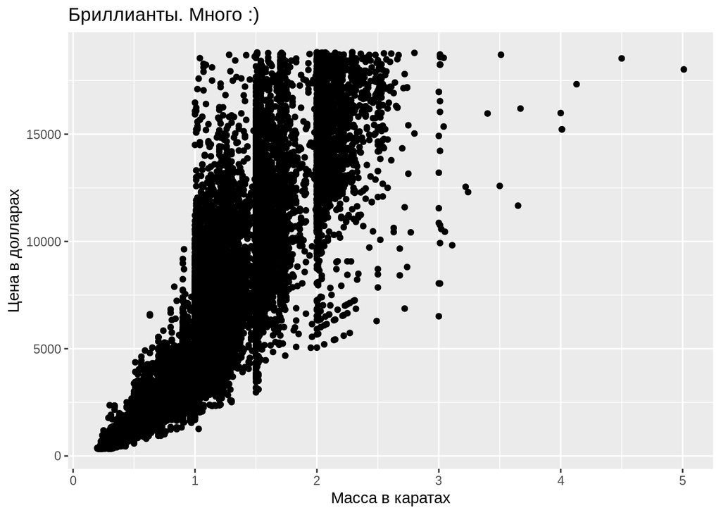

```r
ggplot(data = diamonds) +
  geom_point(aes(x = carat, y = price)) +
  labs(x = 'Масса в каратах', y = 'Цена в долларах', title = 'Бриллианты. Много :)')
```

Задействуем эстетику цвета!

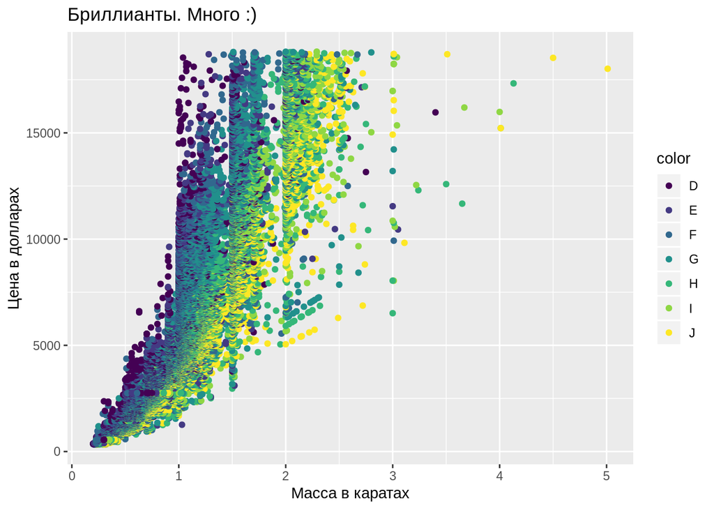

```r
ggplot(data = diamonds) +
  geom_point(aes(x = carat, y = price, color = color)) +
  labs(x = 'Масса в каратах', y = 'Цена в долларах', title = 'Бриллианты. Много :)')
```

Добавим новый слой вертикальных линий! Задействуем эстетику цвета!

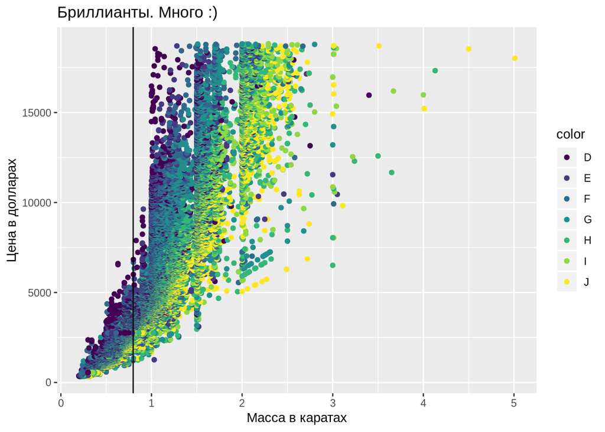

```r
ggplot(data = diamonds) +
  geom_point(aes(x = carat, y = price, color = color)) +
  geom_vline(aes(xintercept = mean(carat))) +
  labs(x = 'Масса в каратах', y = 'Цена в долларах', title = 'Бриллианты. Много :)')
```

- Упражнение 9.

Снова возьмём встроенные данные про машины `mtcars`.

Постройте диаграмму рассеяния сопоставив эстетики графика и переменные так: - координата `x` - пробег в милях на один галлон бензина `mpg` - координата `y` - объём двигателя `disp` - форма `shape` - наличие ручной коробки передач, переменная `am`

```r
# ggplot(data = mtcars) +
#  geom_point(aes(x = ___, ___ = disp, ___ = ___)) +
#  labs(x = 'Пробег в милях на галлон', y = 'Объём двигателя')
```

Добавьте к графику горизонтальную линию на уровне медианного объема двигателя

```r
# ggplot(data = mtcars) +
#  geom_point(aes(x = ___, ___ = disp, ___ = ___)) +
#  geom_hline(aes(yintercept = median(___)))
#  labs(x = 'Пробег в милях на галлон', y = 'Объём двигателя')
```

Нарисуйте гистограмму пробега на одну милю `mpg`:

```r
# ggplot(data = mtcars) +
#  geom_histogram(aes(x = ___)) +
#  labs(x = 'Пробег в милях на галлон', title = 'Няшный график :)')
```

Очень подробная документация по [ggplot](http://ggplot2.tidyverse.org).

Глава про графики в [R for data science](http://r4ds.had.co.nz/graphics-for-communication.html).

# 7 Графики для качественных переменных

Количество цилиндров `cyl` принимает слишком мало значений, поэтому определим `cyl` как факторную переменную. Это действие влияет на то, как строятся графики!

```r
mtcars2 <- mutate(mtcars, cyl = factor(cyl))
```

Посмотрим на распределение расхода бензина на милю (`mpg`) в зависимости от количества цилиндров.

Вместо устаревшего графика “ларь-да-усы” будем строить скрипичный график (violin plot) командой `geom_viloin()` из пакета `ggplot2`.

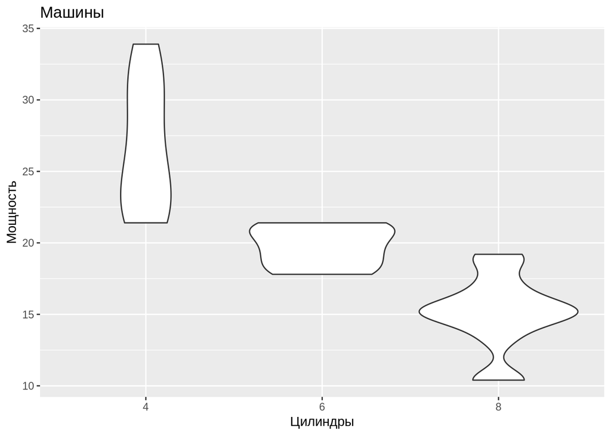

```r
ggplot(data = mtcars2) +
  geom_violin(aes(x = cyl, y = mpg)) +
  labs(x = 'Цилиндры', y = 'Мощность', title = 'Машины')
```

С помощью функции `facet_grid()` можно разбить график на две панели: для ручной и автоматической коробки передач, `am`.

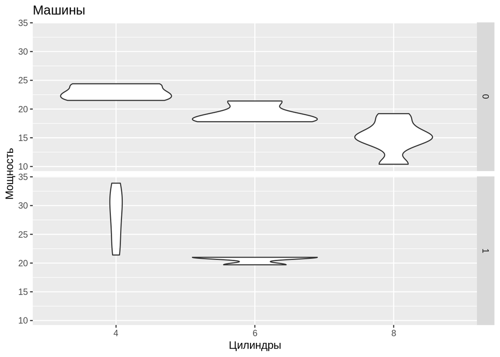

```r
ggplot(data = mtcars2) +
  geom_violin(aes(x = cyl, y = mpg)) +
  facet_grid(am ~ .) +
  labs(x = 'Цилиндры', y = 'Мощность', title = 'Машины')
```

- Упражнение 10.

Добавить новый шмат кода можно через меню `Code` - `Insert chunk`.

- Что изменится в панелях графика, если внутри `facet_grid` написать `. ~ am`?
- Как с клавиатуры без мышки вставить шмат кода?

## 7.1 Потоковый график

И для примера более сложный график с кучей слоёв!

Вспомним старую таблицу частот:

```r
freq_table
```

```
## # A tibble: 20 x 4
## # Groups:   wage, race [?]
##    wage  race   sector        freq
##    <fct> <fct>  <fct>        <int>
##  1 <=50K Female ?              787
##  2 <=50K Female Gov           1361
##  3 <=50K Female Never-worked     2
##  4 <=50K Female Private       7026
##  5 <=50K Female Self_emp       411
##  6 <=50K Female Without-pay      5
##  7 <=50K Male   ?              858
##  8 <=50K Male   Gov           1649
##  9 <=50K Male   Never-worked     5
## 10 <=50K Male   Private      10707
## 11 <=50K Male   Self_emp      1900
## 12 <=50K Male   Without-pay      9
## 13 >50K  Female ?               52
## 14 >50K  Female Gov            278
## 15 >50K  Female Private        726
## 16 >50K  Female Self_emp       123
## 17 >50K  Male   ?              139
## 18 >50K  Male   Gov           1063
## 19 >50K  Male   Private       4237
## 20 >50K  Male   Self_emp      1223
```

Нарисуем две вариации потокового графика с помощью пакета `ggalluvial`

```
## Missing alluvia for some stratum combinations.
## Missing alluvia for some stratum combinations.
## Missing alluvia for some stratum combinations.
```

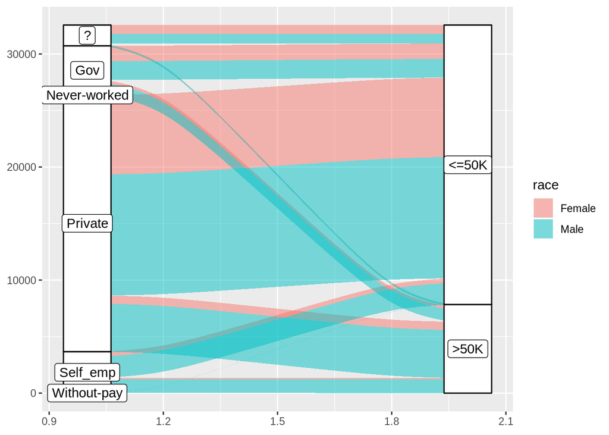

```r
ggplot(data = freq_table,
       aes(weight = freq, axis1 = sector, axis2 = wage)) +
  geom_alluvium(aes(fill = race), width = 1/12) +
  geom_stratum(width = 1/8) +
  geom_label(stat = "stratum", label.strata = TRUE)
```

```
## Missing alluvia for some stratum combinations.
## Missing alluvia for some stratum combinations.
## Missing alluvia for some stratum combinations.
```

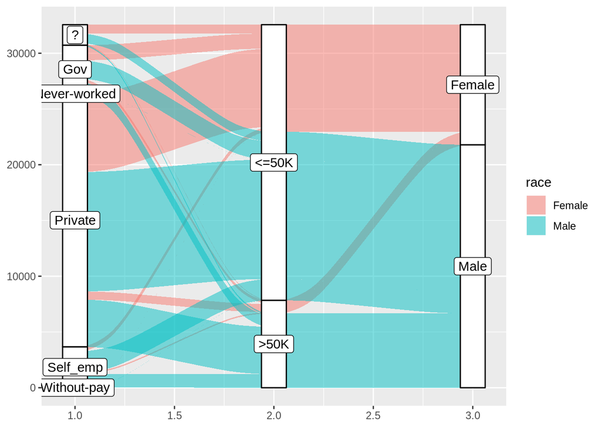

```r
ggplot(data = freq_table,
         aes(weight = freq, axis1 = sector, axis2 = wage, axis3 = race)) +
    geom_alluvium(aes(fill = race), width = 1/12) +
    geom_stratum(width = 1/8) +
    geom_label(stat = "stratum", label.strata = TRUE)
```

- Упражнение 11.
- Какой элемент графика рисует геометрия `geom_stratum`, а какой - геометрия `geom_alluvium`?

Подсказка: просто удалите по очереди каждую из этих строк, и посмотрите, что исчезает!

Вдохновиться примерами и нарисовать себе “такой же, но с перламутровыми пуговицами” [потоковый график](https://cran.r-project.org/web/packages/ggalluvial/vignettes/ggalluvial.html)

Ура :)